# GET00203 - Estatística Computacional 1

Aula 03 - Comparação entre as densidades empírica e teórica

[Rafael Erbisti](https://sites.google.com/site/rerbisti)

## Gerando valores aleatórios

No $\texttt{R}$, o método utilizado para gerar números aleatórios de distribuições de probabilidade é baseado em algoritmos de geração de números pseudoaleatórios.

Esses algoritmos criam sequências de números que aparentam ser aleatórios, mas que, na verdade, são determinados por um valor inicial chamado **semente** (*seed*).

Se você definir uma semente, a sequência de números aleatórios será reprodutível. Isso significa que você sempre obterá a mesma sequência de números se usar a mesma semente.

Para definir a semente, você pode usar a função `set.seed()`:

```r
set.seed(123)  # Define a semente como 123
```

O $\texttt{R}$ utiliza o **método de transformação inversa** para gerar números aleatórios a partir de distribuições diferentes. Esse método começa com um número aleatório de uma distribuição uniforme e o transforma em um número aleatório de outra distribuição aplicando a função inversa da distribuição cumulativa.

#### Método de Transformação Inversa

O método de transformação inversa é uma técnica bastante utilizada para geração de valores aleatórios a partir de uma distribuição de probabilidade específica.

Esse método se baseia na ideia de que, se tivermos a Função de Distribuição Acumulada (FDA) de uma distribuição $F(x)$, é possível obter valores dessa distribuição aplicando a função inversa $F^{-1}(u)$ a números aleatórios $u$ provenientes de uma distribuição uniforme no intervalo $[0,1]$.

##### Passos do Método de Transformação Inversa

1. Gerar um número aleatório uniforme $u$ no intervalo $[0,1]$: esse número será obtido de uma distribuição uniforme.
2. Aplicar a função inversa $F^{−1}(u)$: se $F(x)$ for a função de distribuição acumulada (FDA) da distribuição desejada, então
   $$x= F^{−1}(u)$$
   dará um valor que segue a distribuição $F(x)$.

#### Distribuição Exponencial

A FDA da distribuição exponencial com parâmetro $\lambda$, isto é, $X \sim Exp(\lambda)$, é dada por
$$F(x) = 1- \exp^{-\lambda x}, \ \ \ \ x \geq 0$$
A função inversa da FDA é
$$F^{−1}(u)= −\dfrac{1}{\lambda}\log(1−u)$$
Para gerar valores a partir de uma distribuição exponencial usando o método de transformação inversa, basta fazer o algortimo especificado acima, seguindo os passos:

```r
# Parâmetro lambda
lambda = 2

# Gerar número aleatório uniforme u no intervalo [0, 1]
u = runif(1)

# Aplicar a função inversa da CDF
x = -log(1 - u) / lambda
```

O $\texttt{R}$ já tem a função `rexp()` para fazer isso diretamente de forma otimizada. Abaixo, vamos verificar histogramas dos valores gerados aleatóriamente da distribuição $Exp(2)$ utilizando a função do $\texttt{R}$ e a função construída, conjuntamente com a curva da distribuição teórica.

```r
# Criando a função para gerar valores da Exponencial
rexp.new = function(n, lambda){
  u = runif(n)
  x = -log(1 - u) / lambda
  return(x)}

# Gerando a amostra com a função criada
a.exp.new = rexp.new(n = 200, lambda = 2)

# Gerando a amostra com a função do R
a.exp.r = rexp(n = 200, rate = 2)
```

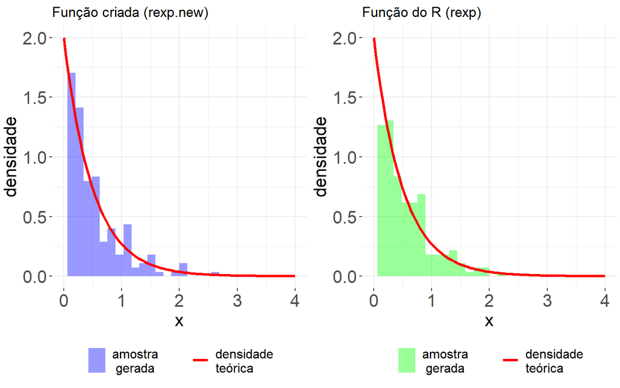

Figura 1. Histogramas das amostras geradas da distribuição Exp(2) e curva de densidade teórica.

```r
# Criando o gráfico com o histograma e sobrepondo a curva de densidade
p1 = ggplot(data = tibble(x = a.exp.new), mapping = aes(x = x)) +
  geom_histogram(aes(y = ..density.., fill = "amostra \n gerada"), alpha = 0.4) +
  stat_function(fun = dexp, args = list(rate = 2), aes(color = "densidade \nteórica"),
                linewidth=1.2) +
  labs(y = "densidade", x = "x", fill = "", color = "", title = "Função criada (rexp.new)") +
  xlim(0, 4) +
  ylim(0, 2) +
  scale_fill_manual(values = c("amostra \n gerada" = "blue")) +
  scale_color_manual(values = c("densidade \nteórica" = "red")) +
  theme_bw() +
  theme(plot.margin = margin(t = 6, r = 3, b = 8, l = 3),
        axis.text.x = element_text(size = 16),
        axis.title.x = element_text(size = 16),
        axis.text.y = element_text(size = 16),
        axis.title.y = element_text(size = 16),
        panel.border = element_blank(),
        legend.position = "bottom",
        legend.text = element_text(size = 12))

p2 = ggplot(data = tibble(x = a.exp.r), mapping = aes(x = x)) +
  geom_histogram(aes(y = ..density.., fill = "amostra \n gerada"), alpha = 0.4) +
  stat_function(fun = dexp, args = list(rate = 2), aes(color = "densidade \nteórica"),
                linewidth=1.2) +
  labs(y = "densidade", x = "x", fill = "", color = "", title = "Função do R (rexp)") +
  xlim(0, 4) +
  ylim(0, 2) +
  scale_fill_manual(values = c("amostra \n gerada" = "green")) +
  scale_color_manual(values = c("densidade \nteórica" = "red")) +
  theme_bw() +
  theme(plot.margin = margin(t = 6, r = 3, b = 8, l = 3),
        axis.text.x = element_text(size = 16),
        axis.title.x = element_text(size = 16),
        axis.text.y = element_text(size = 16),
        axis.title.y = element_text(size = 16),
        panel.border = element_blank(),
        legend.position = "bottom",
        legend.text = element_text(size = 12))

grid.arrange(p1, p2, ncol = 2)
```

#### Limitações

1. Nem todas as distribuições têm uma inversa analítica simples. Para essas distribuições, métodos numéricos ou outros algoritmos (como aceitação e rejeição ou métodos de amostragem específicos) são utilizados.
2. A eficiência do método pode ser limitada quando a função inversa é complexa ou computacionalmente custosa para se calcular.

O **método de transformação inversa** é uma abordagem fundamental para gerar números aleatórios de distribuições conhecidas a partir de números uniformes.

Para distribuições com funções inversas simples (como a exponencial), ele é direto de implementar. No entanto, para distribuições mais complexas (como a Normal), geralmente se usa a função inversa através de bibliotecas numéricas prontas, como a função `qnorm()` no $\texttt{R}$.

#### Distribuição Normal

A FDA de uma variável aleatória contínua $X \sim N(\mu, \sigma^2)$ é definida como

$$F(x) = P(X \leq x) = \int_{-\infty}^{x} f(t) \, dt, \ \ \ \ \ x \in \Re$$
A FDA $F(x)$ pode ser escrita como

$$F(x) = \frac{1}{2} \left( 1 + \text{erf} \left( \frac{x - \mu}{\sigma
\sqrt{2}} \right) \right), \ \ \ \ \ x \in \Re$$

onde:

$$\text{erf}(z) = \frac{2}{\sqrt{\pi}} \int_{0}^{z} e^{-t^2} \, dt$$

Neste caso, claramente, a FDA inversa não tem forma analítica simples, mas métodos numéricos (ou a função `qnorm()`) podem ser utilizadas para solucionar esse problema. O algoritmo do Método de Tranformação Inversa, portanto, é apresentado abaixo

```r
# Gerar número aleatório uniforme u no intervalo [0, 1]
u <- runif(1)

# Gerar número aleatório a partir de uma distribuição normal padrão usando qnorm (inversa da FDA normal)
x <- qnorm(u, mean = 0, sd = 1)
```

O $\texttt{R}$ já tem a função `rnorm()` para fazer a geração de valores aleatórios de forma otimizada. Abaixo, serão apresentados histogramas dos valores gerados da distribuição $N(10,16)$ utilizando a função pronta do $\texttt{R}$ e a função construída, conjuntamente com a curva da distribuição teórica.

```r
# Criando a função para gerar valores da Normal
rnorm.new = function(n, mu, desv){
  u = runif(n)
  x = qnorm(u, mean = mu, sd = desv)
  return(x)}

# Gerando a amostra com a função criada
a.norm.new = rnorm.new(n = 200, mu = 10, desv = 4)

# Gerando a amostra com a função do R
a.norm.r = rnorm(n = 200, mean = 10, sd = 4)
```

[figure not shown]

Figura 2. Histogramas das amostras geradas da distribuição N(10,16) e curva de densidade teórica.

```r
# Criando o gráfico com o histograma e sobrepondo a curva de densidade
p1 = ggplot(data = tibble(x = a.norm.new), mapping = aes(x = x)) +
  geom_histogram(aes(y = ..density.., fill = "amostra \n gerada"), alpha = 0.4) +
  stat_function(fun = dnorm, args = list(mean = 10, sd = 4), aes(color = "densidade \nteórica"),
                linewidth=1.2) +
  labs(y = "densidade", x = "x", fill = "", color = "", title = "Função criada (rnorm.new)") +
  xlim(-5, 25) +
  ylim(0, 0.12) +
  scale_fill_manual(values = c("amostra \n gerada" = "orange")) +
  scale_color_manual(values = c("densidade \nteórica" = "red")) +
  theme_bw() +
  theme(plot.margin = margin(t = 6, r = 3, b = 8, l = 3),
        axis.text.x = element_text(size = 16),
        axis.title.x = element_text(size = 16),
        axis.text.y = element_text(size = 16),
        axis.title.y = element_text(size = 16),
        panel.border = element_blank(),
        legend.position = "bottom",
        legend.text = element_text(size = 12))

p2 = ggplot(data = tibble(x = a.norm.r), mapping = aes(x = x)) +
  geom_histogram(aes(y = ..density.., fill = "amostra \n gerada"), alpha = 0.4) +
  stat_function(fun = dnorm, args = list(mean = 10, sd = 4), aes(color = "densidade \nteórica"),
                linewidth=1.2) +
  labs(y = "densidade", x = "x", fill = "", color = "", title = "Função do R (rnorm)") +
  xlim(-5, 25) +
  ylim(0, 0.12) +
  scale_fill_manual(values = c("amostra \n gerada" = "purple")) +
  scale_color_manual(values = c("densidade \nteórica" = "red")) +
  theme_bw() +
  theme(plot.margin = margin(t = 6, r = 3, b = 8, l = 3),
        axis.text.x = element_text(size = 16),
        axis.title.x = element_text(size = 16),
        axis.text.y = element_text(size = 16),
        axis.title.y = element_text(size = 16),
        panel.border = element_blank(),
        legend.position = "bottom",
        legend.text = element_text(size = 12))

grid.arrange(p1, p2, ncol = 2)
```

#### Distribuição Binomial

A FDA da distribuição binomial com $n$ tentativas e probabilidade de sucesso $p$, $X \sim Binomial(n,p)$, é a soma das probabilidades até um dado valor $x$,
$$F(x)=P(X \leq x)= \sum_{i=0}^{x} \binom{n}{i} p^i (1-p)^{n-i}, \ \ \ \ \
x = 0,1,\ldots,n$$
Para aplicar o método de transformação inversa, basta fazer

1. Gerar um número aleatório $u$ de uma distribuição uniforme $U(0,1)$.
2. Encontrar o menor valor $x$ tal que $F(x)\geq u$, onde $F(x)$ é a FDA da Binomial.

O $\texttt{R}$ já tem a função `rbinom()` para gerar aleatoriamente de forma otimizada. Abaixo, são apresentados os histogramas dos valores gerados da distribuição $Binomial(20,0.7)$ utilizando a função construída e a função `rbinom()`, conjuntamente com a função de probabilidade teórica.

```r
# Criando a função para gerar valores da Binomial
rbinom.new = function(n, size, p){
  u = runif(n)
  x1 = NULL
  for(j in 1:n){
  # calcular manualmente a FDA e encontrar o valor x
  F <- 0       # inicializa a FDA
  x <- 0       # inicializa o valor de x
  while(F < u[j]){
    # calcula a probabilidade P(X = x) para a Binomial
    p_x <- choose(size, x) * p^x * (1 - p)^(size - x)
    # acumula a probabilidade na CDF
    F <- F + p_x
    x <- x + 1}
  # o valor gerado é x - 1 (porque o loop incrementa x antes da última comparação)
  x1[j] <- x - 1}
  return(x1)}

# Gerando a amostra com a função criada
a.binom.new = rbinom.new(n = 100, size = 20, p = 0.7)

# Gerando a amostra com a função do R
a.binom.r = rbinom(n = 100, size = 20, prob = 0.7)
```

Observe que na criação da função para gerar valores aleatórios da Binomial seria possível utilizar a função `qbinom()` para encontrar as probabilidades acumuladas, assim como foi feito com a distribuição Normal. A função pronta do $\texttt{R}$ `qbinom()` já calcula as probabilidades da FDA de maneira otimizada.

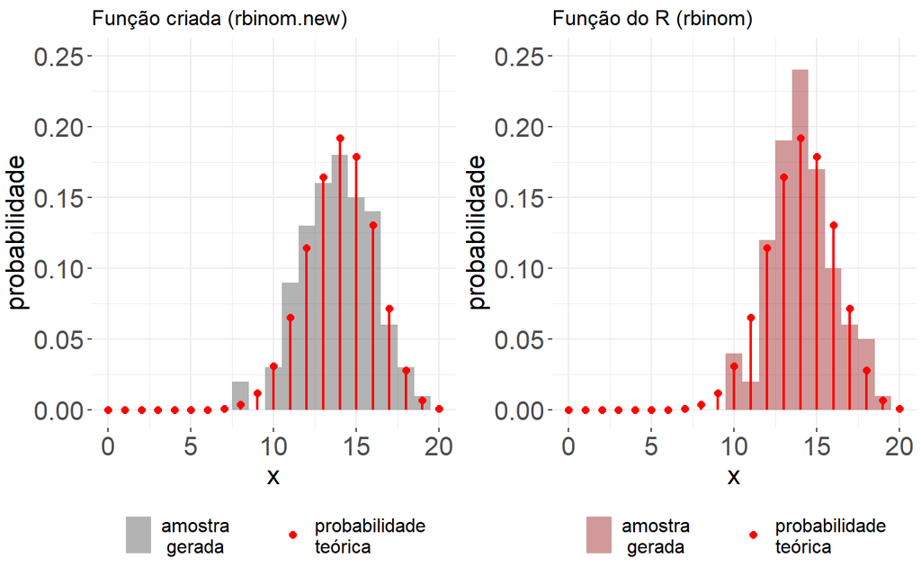

Figura 3. Histogramas das amostras geradas da distribuição Binomial(20,0.7) e função de probabilidade teórica.

```r
# Calculando a função de probabilidade teórica
x_vals <- 0:20
binom_probs <- dbinom(x_vals, size = 20, prob = 0.7)

# Criando um dataframe para plotar a densidade teórica da binomial
theoretical_data <- data.frame(x_vals, binom_probs)

# Criando o gráfico com o histograma e sobrepondo a função de probabilidade
p1 = ggplot(data = tibble(x = a.binom.new), mapping = aes(x = x)) +
  geom_histogram(aes(y = ..density.., fill = "amostra \n gerada"),
                 alpha = 0.4, binwidth = 1, boundary = -0.5) +
    geom_segment(data = theoretical_data, aes(x = x_vals, xend = x_vals, y = 0,
                                              yend = binom_probs), color = "red",
                 linewidth = 0.8) +
  geom_point(data = theoretical_data, aes(x = x_vals, y = binom_probs, color =
                                            "probabilidade \nteórica"), size = 2) +
  labs(y = "probabilidade", x = "x", fill = "", color = "", title = "Função criada (rbinom.new)") +
  xlim(0, 20) +
  ylim(0, 0.25) +
  scale_fill_manual(values = c("amostra \n gerada" = "gray25")) +
  scale_color_manual(values = c("probabilidade \nteórica" = "red")) +
  theme_bw() +
  theme(plot.margin = margin(t = 6, r = 3, b = 8, l = 3),
        axis.text.x = element_text(size = 16),
        axis.title.x = element_text(size = 16),
        axis.text.y = element_text(size = 16),
        axis.title.y = element_text(size = 16),
        panel.border = element_blank(),
        legend.position = "bottom",
        legend.text = element_text(size = 12))

p2 = ggplot(data = tibble(x = a.binom.r), mapping = aes(x = x)) +
  geom_histogram(aes(y = ..density.., fill = "amostra \n gerada"),
                 alpha = 0.4, binwidth = 1, boundary = -0.5) +
  geom_segment(data = theoretical_data, aes(x = x_vals, xend = x_vals, y = 0,
                                              yend = binom_probs), color = "red",
                 linewidth = 0.8) +
  geom_point(data = theoretical_data, aes(x = x_vals, y = binom_probs, color =
                                            "probabilidade \nteórica"), size = 2) +
  labs(y = "probabilidade", x = "x", fill = "", color = "", title = "Função do R (rbinom)") +
  xlim(0, 20) +
  ylim(0, 0.25) +
  scale_fill_manual(values = c("amostra \n gerada" = "darkred")) +
  scale_color_manual(values = c("probabilidade \nteórica" = "red")) +
  theme_bw() +
  theme(plot.margin = margin(t = 6, r = 3, b = 8, l = 3),
        axis.text.x = element_text(size = 16),
        axis.title.x = element_text(size = 16),
        axis.text.y = element_text(size = 16),
        axis.title.y = element_text(size = 16),
        panel.border = element_blank(),
        legend.position = "bottom",
        legend.text = element_text(size = 12))

grid.arrange(p1, p2, ncol = 2)
```

#### Distribuição Poisson

A FDA da distribuição Poisson com parâmetro $\lambda$, $X \sim Poisson(\lambda)$, é dada pela soma das probabilidades $P(X=x)$ até o valor $x$
$$F(x)=P(X\leq x)= \sum_{i=0}^{x} \dfrac{\lambda^i \exp^{-\lambda}}{i!}, \
\ \ \ \ x = 0,1,2,\ldots$$
Assim como na Binomial, para aplicar o método de transformação inversa basta realizar os seguintes passos:

1. Gerar um número aleatório $u$ de uma distribuição uniforme $U(0,1)$.
2. Encontrar o menor valor $x$ tal que $F(x) \geq u$.

O $\texttt{R}$ já tem a função `rpois()` que gera valores aleatórios de forma otimizada. Abaixo, são apresentados os histogramas dos valores gerados da distribuição $Poisson(5)$ utilizando a função construída e a função `rpois()`, conjuntamente com a função de probabilidade teórica.

```r
# Criando a função para gerar valores da Poisson
rpois.new = function(n, lambda){
  u = runif(n)
  x1 = NULL
  for(j in 1:n){
  # calcular manualmente a FDA e encontrar o valor x
  F <- 0       # inicializa a FDA
  x <- 0       # inicializa o valor de x
  p_x <- exp(-lambda)  # P(X = 0) = e^(-lambda)
  while(F < u[j]){
    # acumula a probabilidade na CDF
    F <- F + p_x
    x <- x + 1
    # atualiza a probabilidade P(X = x)
    p_x <- p_x * lambda / x}
  # o valor gerado é x - 1 (porque o loop incrementa x antes da última comparação)
  x1[j] <- x - 1}
  return(x1)}

# Gerando a amostra com a função criada
a.pois.new = rpois.new(n = 100, lambda = 5)

# Gerando a amostra com a função do R
a.pois.r = rpois(n = 100, lambda = 5)
```

Observe que na criação da função para gerar valores aleatórios da Poisson seria possível utilizar a função `qpois()` para encontrar as probabilidades acumuladas, assim como foi feito com as distribuições Normal e Binomial. A função pronta do $\texttt{R}$ `qpois()` já calcula as probabilidades da FDA de maneira otimizada.

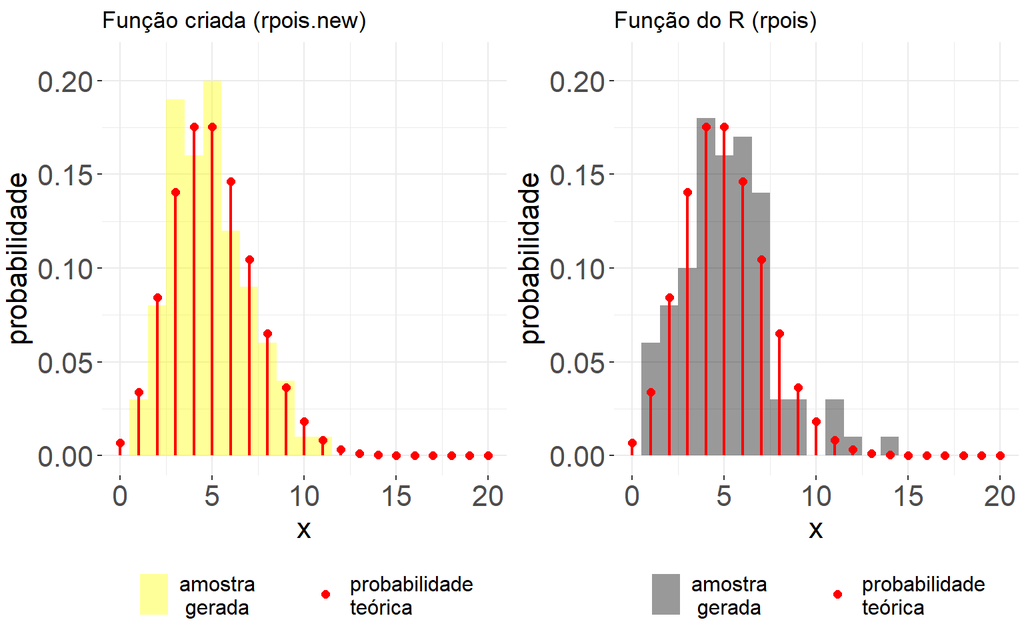

Figura 4. Histogramas das amostras geradas da distribuição Poisson(5) e função de probabilidade teórica.

```r
# Calculando a função de probabilidade teórica
x_vals <- 0:20
pois_probs <- dpois(x_vals, lambda = 5)

# Criando um dataframe para plotar a densidade teórica da Poisson
theoretical_data <- data.frame(x_vals, pois_probs)

# Criando o gráfico com o histograma e sobrepondo a função de probabilidade
p1 = ggplot(data = tibble(x = a.pois.new), mapping = aes(x = x)) +
  geom_histogram(aes(y = ..density.., fill = "amostra \n gerada"),
                 alpha = 0.4, binwidth = 1, boundary = -0.5) +
  geom_segment(data = theoretical_data, aes(x = x_vals, xend = x_vals, y = 0,
                                              yend = pois_probs), color = "red",
                 linewidth = 0.8) +
  geom_point(data = theoretical_data, aes(x = x_vals, y = pois_probs, color =
                                            "probabilidade \nteórica"), size = 2) +
  labs(y = "probabilidade", x = "x", fill = "", color = "", title = "Função criada (rpois.new)") +
  xlim(0, 20) +
  ylim(0, 0.21) +
  scale_fill_manual(values = c("amostra \n gerada" = "yellow")) +
  scale_color_manual(values = c("probabilidade \nteórica" = "red")) +
  theme_bw() +
  theme(plot.margin = margin(t = 6, r = 3, b = 8, l = 3),
        axis.text.x = element_text(size = 16),
        axis.title.x = element_text(size = 16),
        axis.text.y = element_text(size = 16),
        axis.title.y = element_text(size = 16),
        panel.border = element_blank(),
        legend.position = "bottom",
        legend.text = element_text(size = 12))

p2 = ggplot(data = tibble(x = a.pois.r), mapping = aes(x = x)) +
  geom_histogram(aes(y = ..density.., fill = "amostra \n gerada"),
                 alpha = 0.4, binwidth = 1, boundary = -0.5) +
  geom_segment(data = theoretical_data, aes(x = x_vals, xend = x_vals, y = 0,
                                              yend = pois_probs), color = "red",
               linewidth = 0.8) +
  geom_point(data = theoretical_data, aes(x = x_vals, y = pois_probs, color =
                                            "probabilidade \nteórica"), size = 2) +
  labs(y = "probabilidade", x = "x", fill = "", color = "", title = "Função do R (rpois)") +
  xlim(0, 20) +
  ylim(0, 0.21) +
  scale_fill_manual(values = c("amostra \n gerada" = "black")) +
  scale_color_manual(values = c("probabilidade \nteórica" = "red")) +
  theme_bw() +
  theme(plot.margin = margin(t = 6, r = 3, b = 8, l = 3),
        axis.text.x = element_text(size = 16),
        axis.title.x = element_text(size = 16),
        axis.text.y = element_text(size = 16),
        axis.title.y = element_text(size = 16),
        panel.border = element_blank(),
        legend.position = "bottom",
        legend.text = element_text(size = 12))

grid.arrange(p1, p2, ncol = 2)
```

> **Desafio:** Crie uma função para gerar valores da distribuição Uniforme(a,b), baseado do metodo de transformação inversa. Gere uma amostra de tamanho 1000 utilizando a função criada e a função pronta do $\texttt{R}$ de uma $U(10,20)$. Construa histogramas para comparar a distribuição empírica obtida a partir de cada amostra gerada e a curva teórica da $U(10,20)$.